# HW 10

Jillian Sarazen

4/10/2020

1. Using a for loop, write a function to calculate the number of zeroes in a numeric vector. Before entering the loop, set up a counter variable counter <- 0. Inside the loop, add 1 to counter each time you have a zero in the matrix. Finally, use return(counter) for the output.

```r
# ---------------------------------------------
# FUNCTION zero_counter
# description: counts the number of zeros in a vector
# inputs: vec1, a vector containing a certain number of whole numbers
# outputs: a vector counter, which gives the number of zeros in vec1
###############################################

zero_counter <- function(vec1=vec1) {

  counter <- 0 # setting up the counter vector which will be added to

for (i in seq_along(vec1)) {
  if(vec1[i]==0) counter <- counter+1  else  # if i is zero, add 1 to the counter. else takes to next line
  if(vec1[i]!=0) counter <- counter+0 # if i is not 0, add zero to counter
  }
return(counter)
} # end of zero_counter
#----------------------------------------------

# checking the function
n <- 50
vec1 <- sample(0:1,n, replace = TRUE)
zero_counter(vec1)
```

```
## [1] 24
```

```r
# this works!!
```

2. Use subsetting instead of a loop to rewrite the function as a single line of code.

```r
# set up vec1 like above
n <- 50
vec1 <- sample(0:1,n, replace = TRUE)

# make a vector, that uses length() to tell us the number of values in vec1 where vec1=0
zero_subset <- length(vec1[vec1==0])
print(zero_subset)
```

```
## [1] 19
```

```r
# this works!
```

3. Write a function that takes as input two integers representing the number of rows and columns in a matrix. The output is a matrix of these dimensions in which each element is the product of the row number x the column number.

```r
# ---------------------------------------------
# FUNCTION row_col_calculator
# description: creates a matrix of where the values is each a product of the row number * the column number
# inputs: two integers representing the number of rows and columns in a matrix
# outputs: matrix where each element is the product of row number * column number
###############################################

row_col_calculator <- function(a, b) {     # inputs are a and b, vectors for number of rows and columns

m3 <- matrix(nrow=a,ncol=b)  # make the matrix

# make double loop for rows and columns
  for (i in 1:a) { # start of outer loop
    for (j in 1:b) { # start of inner loop
      m3[i,j] <- i*j  # for each round through the matrix, multiply i*j
}
}

return(m3)

} # end of row_col_calculator
#----------------------------------------------

# checking that this works...
a <- 3
b <- 4
row_col_calculator(a, b)
```

```
##      [,1] [,2] [,3] [,4]
## [1,]    1    2    3    4
## [2,]    2    4    6    8
## [3,]    3    6    9   12
```

```r
# loop works!
```

4. Use the code from the upcoming April 2nd lecture (Randomization Tests) to design and conduct a randomization test for some of your own data. You will need to modify the functions that read in the data, calculate the metric, and randomize the data. Once those are set up, the program should run correctly calling your new functions. Also, to make your analysis fully repeatable, make sure you set the random number seed at the beginning (use either set.seed() in base R, or char2seed in the TeachingDemos package

```r
# for this going to compare my silage treatment system inflow TN data vs. East Bioreactor (EB) outflow TN data

# Preliminaries --------------------------------

library(ggplot2)
library(TeachingDemos)
library(reshape2)

# random number generator setting up
char2seed("coffee") # set the seed for the day

# doing an example of this first outside of the functions

# read in data (already have it)
setwd("/Users/Jill/Desktop/Silage_R_New")
S_2019 <- read.csv("Silage_Hydrology_Table_2019.csv", header = TRUE)

# name columns as vectors
InflowTN <- S_2019$S1_TN_mg_L
EB_TN <- S_2019$S4_TN_mg_L
Date <- S_2019$StartDate

# combine the data frames
df1 <- data.frame(Date, InflowTN, EB_TN)
df2 <- melt(df1, id.vars='Date')
print(df2)
```

```
##      Date variable    value
## 1  20-Jun InflowTN  64.7400
## 2  25-Jun InflowTN 121.5400
## 3  29-Jun InflowTN  68.3400
## 4  11-Jul InflowTN  90.9400
## 5  28-Jul InflowTN  49.5400
## 6   7-Aug InflowTN  53.1400
## 7  17-Aug InflowTN  39.1400
## 8  21-Aug InflowTN  35.5400
## 9  28-Aug InflowTN  50.1400
## 10  2-Sep InflowTN  37.7400
## 11 23-Sep InflowTN  66.9400
## 12 26-Sep InflowTN  39.5400
## 13  1-Oct InflowTN  33.9400
## 14  7-Oct InflowTN  18.8050
```

[output cut: 18 more lines]

```r
# look at means in the two groups, using the df2 from above
obs <- tapply(df2$value, df2$variable,  mean)
# this function first wants the data (this case the response variable) then the grouping variable. and then give it the function that it is going to apply to that subset of the data
# print(obs) # note that this doesn't work with the InflowTN data because there are NAs


# create a simulated data set --------------------------------

# set up a new data frame
df_sim <- df2
df_sim$value <- sample(df_sim$value)
# sample reorders the values, keeps the same number of values in each group though
#print(df_sim)

# look at the means in the two groups of randomized data
sim <- tapply(df_sim$value ,df_sim$variable, mean)
# print(sim)
# the difference between these groups is not as different, by chance we can get a difference this big



# Build functions --------------------------------


# ---------------------------------------------
# FUNCTION read_data
# description: read in (or generate) data set for analysis
# inputs: file name (or nothing, as in this demo)
# outputs: 3 column data frame of observed data (ID, x, y )
###############################################
read_data <- function(z=NULL) {

  df <- read.csv(file=z, # use z
                   header = TRUE)
                   #stringsAsFactors = FALSE,
                   #fill = TRUE)

   # name columns as vectors
InflowTN <- df$S1_TN_mg_L
EB_TN <- df$S4_TN_mg_L
Date <- df$StartDate

# combine the data frames
df1 <- data.frame(Date, InflowTN, EB_TN)
df2 <- melt(df1, id.vars='Date')
return(df2)


} # end of read_data
#----------------------------------------------
# mydata <- read_data(z="Silage_Hydrology_Table_2019.csv")
# could add fill = TRUE in read.table function


# ---------------------------------------------
# FUNCTION get_aov
# description: calculate ANOVA for randomization test to get P val
# inputs: 3-column data frame for ANOVA: (headings=Date, variable, value)
# outputs: P value
###############################################
get_aov <- function(z=NULL) {

  . <- aov(value~variable,data=z)
  . <- summary(.)
  . <- unlist(.)
  pval <- (.)[9]
  return(pval)


} # end of get_aov
#----------------------------------------------
# m <- get_aov(mydata)

## . is a temporary holder

#####################################################
# what is coming in to this function is the original data, and what is coming out is the randomized version
# ---------------------------------------------
# FUNCTION shuffle_data
# description: randomize value column
# inputs: 3 column data frame (Data, variable, value)
# outputs: 3 column data frame (ID, variable, value)
###############################################
shuffle_data <- function(z=NULL) {

z[,3] <- sample(z[,3])

return(z)

} # end of shuffle_data
#----------------------------------------------

# ---------------------------------------------
# FUNCTION get_pval
# description: calculate p value from simulation
# inputs: List of observed metric and vector of simulated metrics
# outputs: lower and upper tail probability value
###############################################
get_pval <- function(z=NULL) {
  p_lower <- mean(z[[2]]<=z[[1]]) ### asking what is the proportion of the 1000 cases we are looking at for which the simulated value is less thatn the observed value - lower tail probability
  p_upper <- mean(z[[2]]>=z[[1]])


return(c(pL=p_lower,pU=p_upper))
} # end of get_pval
#----------------------------------------------
# get_pval() # pvalues together add up to 1

# ---------------------------------------------
# FUNCTION plot_ran_test
# description: create a ggplot of histogram of simulated values
# inputs: list of observed metric and vector simulated metrics
# outputs: saved ggplot graph
###############################################
plot_ran_test <- function(z=NULL) {
  df <- data.frame(ID=seq_along(z[[2]]), sim_x=z[[2]])
  p1 <- ggplot(data=df, mapping=aes(x=sim_x))
  p1 + geom_histogram(mapping=aes(fill=I("goldenrod"),
                                  color=I("black"))) +
    geom_vline(aes(xintercept=z[[1]],col="blue"))

} # end of plot_ran_test
#----------------------------------------------



# running the code! --------------------------------

char2seed("coffee")
n_sim <- 1000 # number of simulated data sets
x_sim <- rep(NA,n_sim) # set up empty vector for simulated slopes

df <- read_data("Silage_Hydrology_Table_2019.csv") # get data
x_obs <- get_aov(df) # get pval and F stat of observed data

# (seq_len looks for a single number that creates a sequence)
for (i in seq_len(n_sim)) {
  x_sim[i] <- get_aov(shuffle_data(df)) # run similation
}

slopes <- list(x_obs,x_sim)
get_pval(slopes)
```

```
##   pL   pU
## 0.22 0.78
```

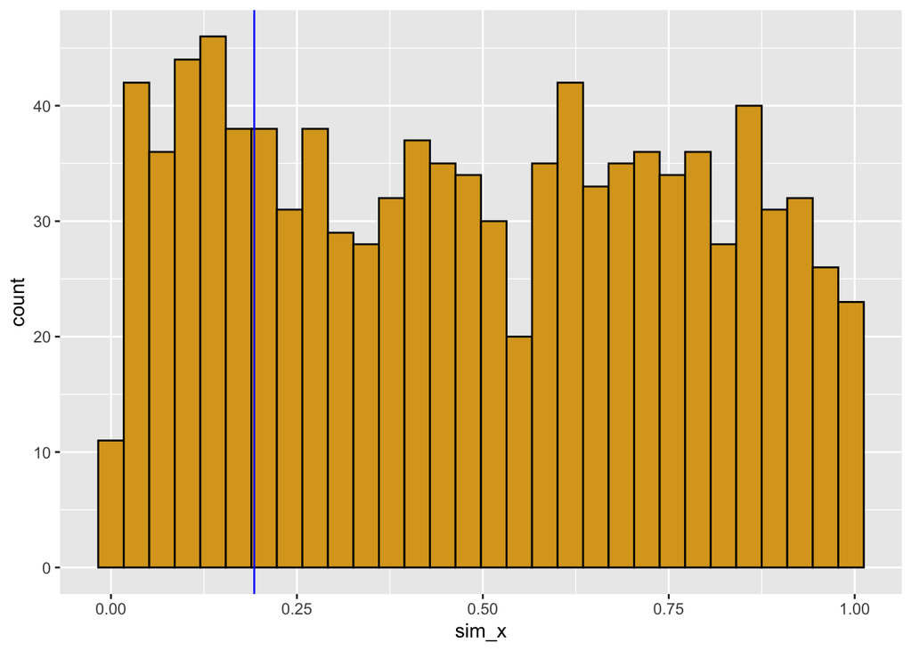

```r
plot_ran_test(slopes)
```

```r
# After running this a few times, it seems that most of the time the x_sim value is on the upper end


# question 5 (in the same R section b/c of function calls) --------------------------------

df <- read_data("Silage_Hydrology_Table_2019.csv") # get data
x_obs <- get_aov(df)
print(x_obs)
```

```
##   Pr(>F)1
## 0.1926571
```

5. For comparison, calculate in R the standard statistical analysis you would use with these data. How does the p-value compare for the standard test versus the p value you estimated from your randomization test? If the p values seem very different, run the program again with a different starting seed (and/or increase the number of replications in your randomization test). If there are persistent differences in the p value of the standard test versus your randomization, what do you think is responsible for this difference?

see above at the end of the last R section

The pvalue that I get from running an anova on this data set is not < 0.05, so we would not reject the null for this test too, which is consistent with what the randomization test gives us too